# Collecting Data

```python
import pandas as pd
mcdonalds = pd.read_csv('mcdonalds.csv')
print(mcdonalds.columns)
```

```
Index(['yummy', 'convenient', 'spicy', 'fattening', 'greasy', 'fast', 'cheap',
       'tasty', 'expensive', 'healthy', 'disgusting', 'Like', 'Age',
       'VisitFrequency', 'Gender'],
      dtype='object')
```

```python
mcdonalds.head(5)
```

|  | yummy | convenient | spicy | fattening | greasy | fast | cheap | tasty | expensive | healthy | disgusting | Like | Age | VisitFrequency | Gender |
| --- | --- | --- | --- | --- | --- | --- | --- | --- | --- | --- | --- | --- | --- | --- | --- |
| 0 | No | Yes | No | Yes | No | Yes | Yes | No | Yes | No | No | -3 | 61 | Every three months | Female |
| 1 | Yes | Yes | No | Yes | Yes | Yes | Yes | Yes | Yes | No | No | +2 | 51 | Every three months | Female |
| 2 | No | Yes | Yes | Yes | Yes | Yes | No | Yes | Yes | Yes | No | +1 | 62 | Every three months | Female |
| 3 | Yes | Yes | No | Yes | Yes | Yes | Yes | Yes | No | No | Yes | +4 | 69 | Once a week | Female |
| 4 | No | Yes | No | Yes | Yes | Yes | Yes | No | No | Yes | No | +2 | 49 | Once a month | Male |

```python
mcdonalds.info()
```

```
<class 'pandas.core.frame.DataFrame'>
RangeIndex: 1453 entries, 0 to 1452
Data columns (total 15 columns):
 #   Column          Non-Null Count  Dtype
---  ------          --------------  -----
 0   yummy           1453 non-null   object
 1   convenient      1453 non-null   object
 2   spicy           1453 non-null   object
 3   fattening       1453 non-null   object
 4   greasy          1453 non-null   object
 5   fast            1453 non-null   object
 6   cheap           1453 non-null   object
 7   tasty           1453 non-null   object
 8   expensive       1453 non-null   object
 9   healthy         1453 non-null   object
 10  disgusting      1453 non-null   object
 11  Like            1453 non-null   object
 12  Age             1453 non-null   int64
 13  VisitFrequency  1453 non-null   object
 14  Gender          1453 non-null   object
dtypes: int64(1), object(14)
memory usage: 170.4+ KB
```

### Preprocessing

```python
dm=pd.get_dummies(mcdonalds)
dm.sample(10)
```

|  | Age | yummy_No | yummy_Yes | convenient_No | convenient_Yes | spicy_No | spicy_Yes | fattening_No | fattening_Yes | greasy_No | ... | Like_I hate it!-5 | Like_I love it!+5 | VisitFrequency_Every three months | VisitFrequency_More than once a week | VisitFrequency_Never | VisitFrequency_Once a month | VisitFrequency_Once a week | VisitFrequency_Once a year | Gender_Female | Gender_Male |
| --- | --- | --- | --- | --- | --- | --- | --- | --- | --- | --- | --- | --- | --- | --- | --- | --- | --- | --- | --- | --- | --- |
| 1440 | 55 | 0 | 1 | 0 | 1 | 1 | 0 | 1 | 0 | 1 | ... | 0 | 0 | 0 | 0 | 0 | 1 | 0 | 0 | 1 | 0 |
| 1233 | 60 | 1 | 0 | 0 | 1 | 1 | 0 | 0 | 1 | 0 | ... | 0 | 0 | 0 | 0 | 1 | 0 | 0 | 0 | 1 | 0 |
| 33 | 37 | 1 | 0 | 0 | 1 | 1 | 0 | 0 | 1 | 0 | ... | 0 | 0 | 0 | 0 | 1 | 0 | 0 | 0 | 0 | 1 |
| 1147 | 48 | 1 | 0 | 0 | 1 | 1 | 0 | 0 | 1 | 0 | ... | 0 | 0 | 0 | 0 | 0 | 0 | 0 | 1 | 1 | 0 |
| 1379 | 45 | 1 | 0 | 0 | 1 | 1 | 0 | 1 | 0 | 1 | ... | 0 | 0 | 0 | 0 | 0 | 0 | 0 | 1 | 0 | 1 |
| 255 | 56 | 0 | 1 | 0 | 1 | 0 | 1 | 0 | 1 | 1 | ... | 0 | 0 | 0 | 0 | 0 | 1 | 0 | 0 | 1 | 0 |
| 37 | 49 | 1 | 0 | 0 | 1 | 1 | 0 | 0 | 1 | 0 | ... | 1 | 0 | 1 | 0 | 0 | 0 | 0 | 0 | 1 | 0 |
| 607 | 45 | 0 | 1 | 0 | 1 | 1 | 0 | 0 | 1 | 1 | ... | 0 | 0 | 0 | 0 | 0 | 1 | 0 | 0 | 0 | 1 |
| 828 | 57 | 1 | 0 | 0 | 1 | 1 | 0 | 0 | 1 | 0 | ... | 0 | 0 | 0 | 0 | 0 | 0 | 0 | 1 | 0 | 1 |
| 276 | 47 | 1 | 0 | 0 | 1 | 1 | 0 | 0 | 1 | 1 | ... | 0 | 0 | 0 | 0 | 0 | 0 | 0 | 1 | 0 | 1 |

10 rows × 42 columns

```python
mcdonalds.yummy=mcdonalds.yummy.map(dict(Yes=1, No=0))
mcdonalds.convenient=mcdonalds.convenient.map(dict(Yes=1, No=0))
mcdonalds.spicy=mcdonalds.spicy.map(dict(Yes=1, No=0))
mcdonalds.fattening=mcdonalds.fattening.map(dict(Yes=1, No=0))
mcdonalds.greasy=mcdonalds.greasy.map(dict(Yes=1, No=0))
mcdonalds.fast=mcdonalds.fast.map(dict(Yes=1, No=0))
mcdonalds.cheap=mcdonalds.cheap.map(dict(Yes=1, No=0))
mcdonalds.tasty=mcdonalds.tasty.map(dict(Yes=1, No=0))
mcdonalds.expensive=mcdonalds.expensive.map(dict(Yes=1, No=0))
mcdonalds.healthy=mcdonalds.healthy.map(dict(Yes=1, No=0))
mcdonalds.disgusting=mcdonalds.disgusting.map(dict(Yes=1, No=0))
```

```python
mcdonalds_new=mcdonalds.drop(['Like', 'Age', 'VisitFrequency', 'Gender'], axis = 1)
```

```python
mcdonalds_new.columns
```

```
Index(['yummy', 'convenient', 'spicy', 'fattening', 'greasy', 'fast', 'cheap',
       'tasty', 'expensive', 'healthy', 'disgusting'],
      dtype='object')
```

```python
mcdonalds_like=mcdonalds['Like']
mcdonalds_like.sample(10)
```

```
4                 +2
278               +4
198               +1
209               -3
1040               0
942               -2
898               +4
1409    I love it!+5
761               -1
909                0
Name: Like, dtype: object
```

```python
for i in range(len(mcdonalds_like)):
  if mcdonalds_like[i]=='I hate it!-5':
     mcdonalds_like[i]=-5
  if mcdonalds_like[i]=='I love it!+5':
     mcdonalds_like[i]=5
```

```python
mcdonalds_new_normalized=(mcdonalds_new - mcdonalds_new.mean()) / mcdonalds_new.std()
```

# Exploring Data

```python
import numpy as np

MD_x = np.array(mcdonalds.iloc[:, 0:11])
np.round(np.mean(MD_x, axis=0), 2)
```

```
array([0.55, 0.91, 0.09, 0.87, 0.53, 0.9 , 0.6 , 0.64, 0.36, 0.2 , 0.24])
```

```python
from sklearn.decomposition import PCA

MD_pca = PCA().fit(MD_x)
print(MD_pca.explained_variance_ratio_)
```

```
[0.29944723 0.19279721 0.13304535 0.08309578 0.05948052 0.05029956
 0.0438491  0.03954779 0.0367609  0.03235329 0.02932326]
```

```python
pca = PCA(n_components = 2)
```

```python
pca.fit(MD_x)
```

```
PCA(n_components=2)
```

```python
x_pca = pca.transform(MD_x)
print(x_pca.shape)
print(MD_x.shape)
```

```
(1453, 2)
(1453, 11)
```

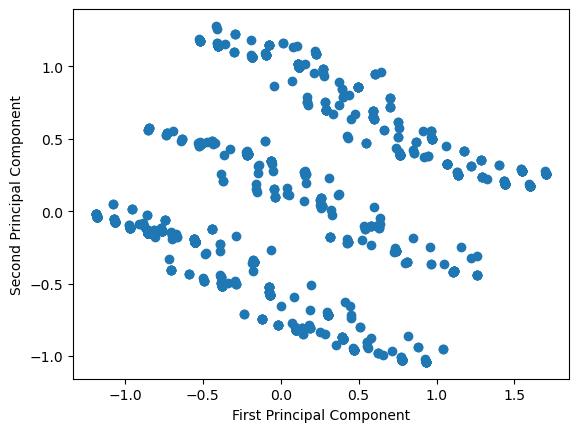

```python
import matplotlib.pyplot as plt
plt.scatter(x_pca[:,0],x_pca[:,1])
plt.xlabel('First Principal Component')
plt.ylabel('Second Principal Component')
```

# Extracting Segments

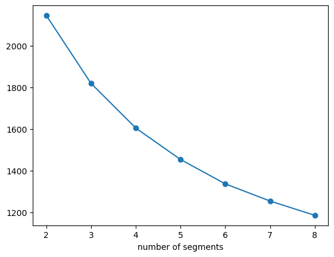

```python
from sklearn.cluster import KMeans
np.random.seed(1234)
MD_kms = []
for i in range(2, 9):
    km = KMeans(n_clusters=i, n_init=10, verbose=False)
    km.fit(MD_x)
    MD_kms.append(km)

plt.figure()
plt.plot(range(2, 9), [km.inertia_ for km in MD_kms], marker='o')
plt.xlabel('number of segments')
plt.show()
```

```python
x = mcdonalds_new.loc[:,['yummy','tasty','convenient','fattening','greasy','fast','cheap','tasty','expensive','healthy','disgusting']].values
x
```

```
array([[0, 0, 1, ..., 1, 0, 0],
       [1, 1, 1, ..., 1, 0, 0],
       [0, 1, 1, ..., 1, 1, 0],
       ...,
       [1, 1, 1, ..., 1, 0, 0],
       [1, 1, 1, ..., 0, 1, 0],
       [0, 0, 1, ..., 1, 0, 1]], dtype=int64)
```

```python
kmeans=KMeans(n_clusters=4)
kmeans.fit(x)
pr=kmeans.predict(x)
print(kmeans.labels_[:100])
```

```
[1 3 3 0 1 0 3 0 2 3 1 3 1 3 2 0 0 3 2 3 3 0 3 3 0 1 0 3 1 0 0 0 0 1 0 1 0
 1 1 2 3 0 0 0 1 3 0 3 0 0 2 1 3 2 0 0 1 1 0 0 3 0 0 2 0 2 2 3 0 0 1 0 3 0
 0 2 0 2 3 0 1 0 0 0 3 0 3 3 3 0 0 0 2 0 0 3 0 1 2 0]
```

```python
kmeans.cluster_centers_[:100]
```

```
array([[8.17292007e-01, 1.00000000e+00, 9.77161501e-01, 8.10766721e-01,
        3.84991843e-01, 9.64110930e-01, 9.36378467e-01, 1.00000000e+00,
        1.63132137e-02, 2.96900489e-01, 6.68841762e-02],
       [1.01010101e-01, 7.77156117e-16, 8.98989899e-01, 9.12457912e-01,
        5.89225589e-01, 9.46127946e-01, 8.45117845e-01, 7.77156117e-16,
        3.36700337e-02, 9.09090909e-02, 3.90572391e-01],
       [8.18181818e-02, 4.44089210e-16, 6.54545455e-01, 9.00000000e-01,
        7.00000000e-01, 7.00000000e-01, 5.00000000e-02, 4.44089210e-16,
        9.54545455e-01, 5.90909091e-02, 6.36363636e-01],
       [7.86377709e-01, 1.00000000e+00, 9.56656347e-01, 9.10216718e-01,
        6.19195046e-01, 8.73065015e-01, 1.05263158e-01, 1.00000000e+00,
        8.97832817e-01, 2.07430341e-01, 1.73374613e-01]])
```

```python
label=kmeans.labels_
label
```

```
array([1, 3, 3, ..., 3, 0, 2])
```

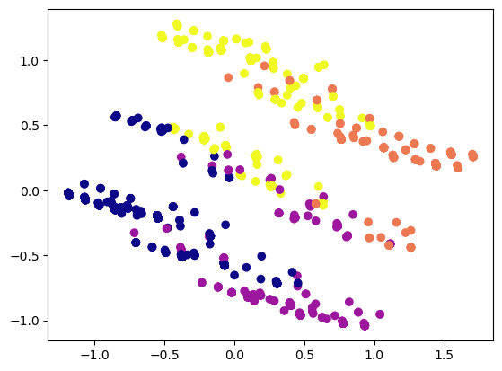

```python
ppca = pd.DataFrame(data = x_pca, columns = [ 'pc1', 'pc2'])
plt.scatter(ppca['pc1'], ppca['pc2'], c=pr, cmap='plasma')
```

```python
mcdonalds_new['cluster']=label
mcdonalds_new
```

|  | yummy | convenient | spicy | fattening | greasy | fast | cheap | tasty | expensive | healthy | disgusting | cluster |
| --- | --- | --- | --- | --- | --- | --- | --- | --- | --- | --- | --- | --- |
| 0 | 0 | 1 | 0 | 1 | 0 | 1 | 1 | 0 | 1 | 0 | 0 | 1 |
| 1 | 1 | 1 | 0 | 1 | 1 | 1 | 1 | 1 | 1 | 0 | 0 | 3 |
| 2 | 0 | 1 | 1 | 1 | 1 | 1 | 0 | 1 | 1 | 1 | 0 | 3 |
| 3 | 1 | 1 | 0 | 1 | 1 | 1 | 1 | 1 | 0 | 0 | 1 | 0 |
| 4 | 0 | 1 | 0 | 1 | 1 | 1 | 1 | 0 | 0 | 1 | 0 | 1 |
| ... | ... | ... | ... | ... | ... | ... | ... | ... | ... | ... | ... | ... |
| 1448 | 0 | 1 | 0 | 1 | 1 | 0 | 0 | 0 | 1 | 0 | 1 | 2 |
| 1449 | 1 | 1 | 0 | 1 | 0 | 0 | 1 | 1 | 0 | 1 | 0 | 0 |
| 1450 | 1 | 1 | 0 | 1 | 0 | 1 | 0 | 1 | 1 | 0 | 0 | 3 |
| 1451 | 1 | 1 | 0 | 0 | 0 | 1 | 1 | 1 | 0 | 1 | 0 | 0 |
| 1452 | 0 | 1 | 0 | 1 | 1 | 0 | 0 | 0 | 1 | 0 | 1 | 2 |

1453 rows × 12 columns

```python
from sklearn.linear_model import LinearRegression
from sklearn.metrics import r2_score, mean_squared_error
```

```python
x_pca= pca.fit_transform(mcdonalds_new_normalized)
```

```python
lm = LinearRegression()
lm.fit(x_pca, mcdonalds_like)
```

```
LinearRegression()
```

```python
y_pred = lm.predict(x_pca)
r2_score(mcdonalds_like, y_pred)
```

```
0.5749736968967734
```

```python
y_mse = mean_squared_error(mcdonalds_like, y_pred)
y_mse
```

```
4.126163610238528
```

# Profiling Segments

```
array([[<Axes: title={'center': 'yummy'}>,
        <Axes: title={'center': 'convenient'}>,
        <Axes: title={'center': 'spicy'}>],
       [<Axes: title={'center': 'fattening'}>,
        <Axes: title={'center': 'greasy'}>,
        <Axes: title={'center': 'fast'}>],
       [<Axes: title={'center': 'cheap'}>,
        <Axes: title={'center': 'tasty'}>,
        <Axes: title={'center': 'expensive'}>],
       [<Axes: title={'center': 'healthy'}>,
        <Axes: title={'center': 'disgusting'}>, <Axes: >]], dtype=object)
```

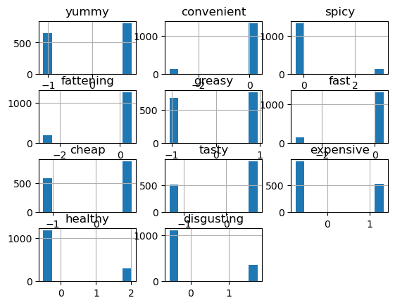

```python
mcdonalds_new_normalized.hist()
```

# Describing Segments

```python
from statsmodels.graphics.mosaicplot import mosaic
from itertools import product
```

```python
list = ['yummy','tasty','convenient','fattening','greasy','fast','cheap','tasty','expensive','healthy','disgusting']
```

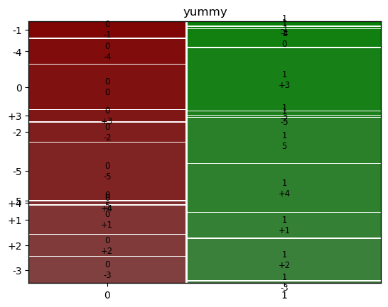

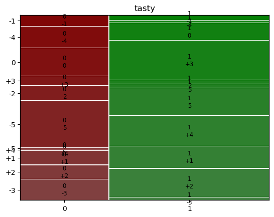

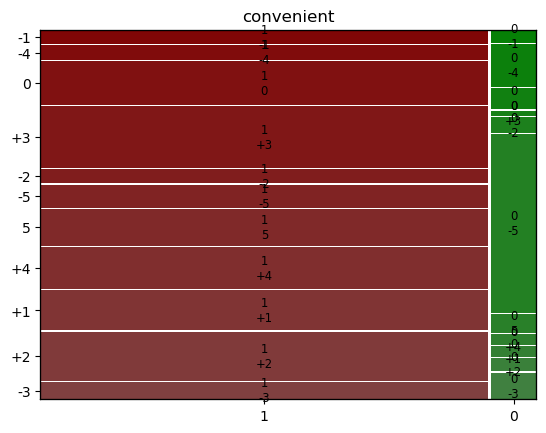

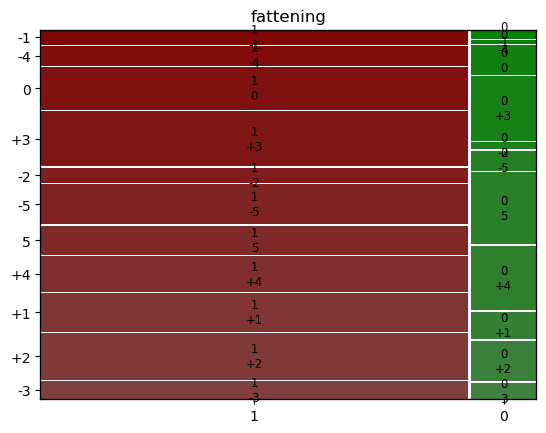

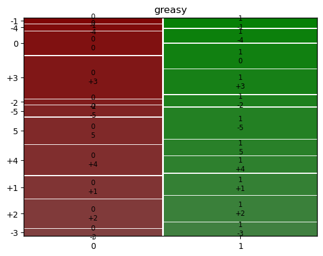

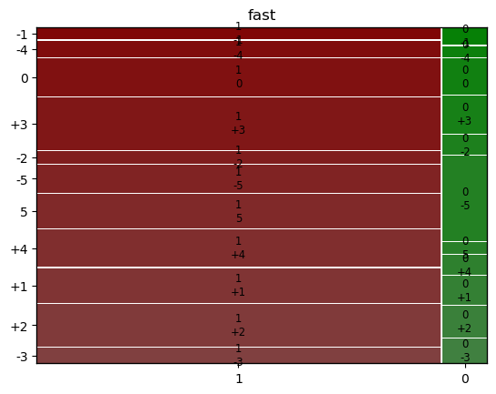

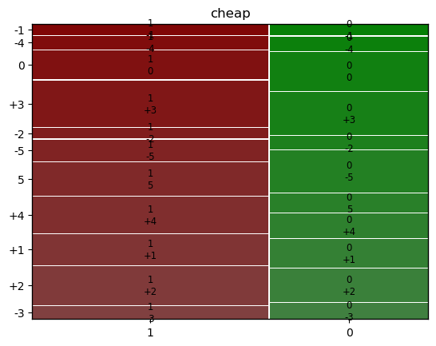

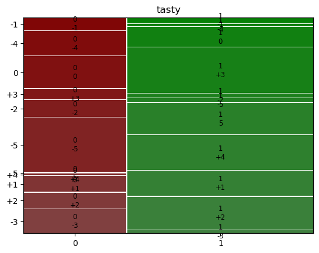

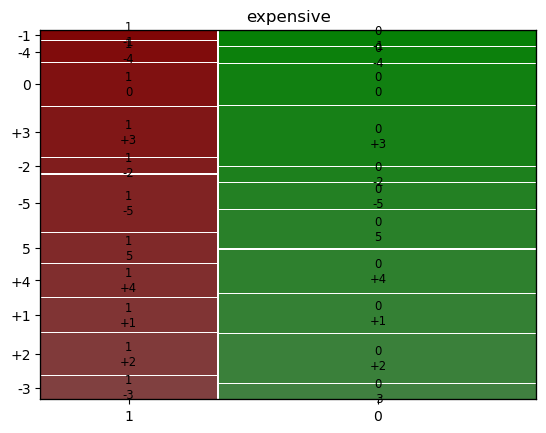

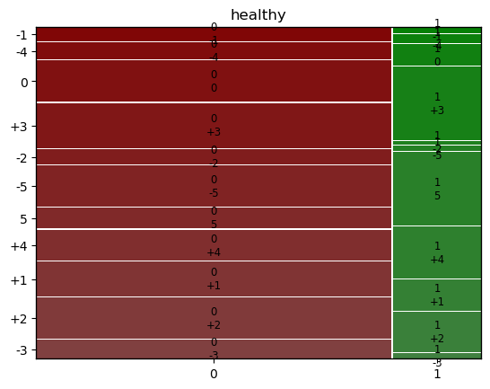

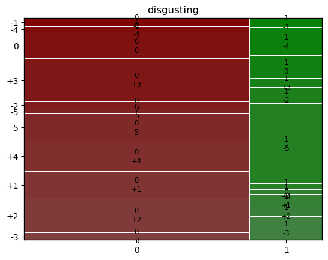

```python
for i in list:
  mosaic(mcdonalds,[i , 'Like'],title = i)
  plt.show()
```

# Selecting (The) Target Segment(s)

Users of the market segmentation (McDonald's management) can now move on to build a segment evaluation plot using the knock-out criterion and segment attractiveness criteria described in Step 2.

# Customising the Marketing Mix

The marketing mix is designed in Step 9. For instance, if McDonald's managers choose to concentrate on segment 3 (young customers who enjoy McDonald's, think the food is delicious and tasty, but perceive it to be fairly expensive), they may decide to offer an MCSUPERBUDGET line to specifically address their segment's expectations regarding price (4Ps: Price). The benefit of such a strategy may be that segment 3 members grow to be devoted patrons who, when they begin earning more money, will no longer be concerned about the price and switch to the standard McDonald's variety of products. The product features of the MCSUPERBUDGET range would need to be distinctly different from the main range (4Ps: Product) in order to avoid cannibalising the main range. The next step would be to identify the communication channels that segment 3 members frequently utilise to spread the word about the MCSUPERBUDGET line's availability (4Ps: Promotion). Given that all McDonald's food is offered in McDonald's outlets, distribution channels (4Ps: Place) would have to be the same for all of the McDonald's products. To avoid cannibalising its main product line, McDonald's management may want to consider adding an MCSUPERBUDGET lane where customers may have to wait a little bit longer.

# Evaluation and Monitoring

The success of the market segmentation strategy must be assessed, and the market must be closely watched on a continuing basis, after the market segmentation analysis is finished and all strategic and tactical marketing actions have been carried out. For instance, section 3 members might begin to make more money and find that the MCSUPERBUDGET line is no longer appropriate for them. Existing market segments may undergo changes. However, alterations may also take place in the bigger market, for instance, if new rivals enter the industry. In order to detect changes that necessitate McDonald's management adjusting their strategy or tactical marketing in light of changing market circumstances, all potential sources of change must be closely examined.